# Исследование структуры временных рядов в R (практика)

### Преобразование Бокса-Кокса

Помимо логарифмирования, можно применять и другие преобразования ряда, чтобы уменьшить зависимость амплитуды колебаний от уровня ряда. Например, применяются **степенные преобразования** (**power transformations**):

$$w_t = y_t ^ {p},$$

где
$$p \in \{\frac{1}{2}, \frac{1}{3}, -1 \}.$$

Бокс и Кокс предложили удобный способ описания целого семейства преобразований, включающего степенные преобразования и логарифмирование с помощью параметра $\lambda$.

**Преобразование Бокса-Кокса** (**Box-Cox transformation**) задается следующим образом:

$$w_t =
\begin{cases}
\log{y} & \text{при } \lambda = 0 \\
(y_t^\lambda - 1) / \lambda & \text{иначе.}
\end{cases}$$

Логарфм используется натуральный.

Для преобразования временных рядов в R имеется функция `forecast::BoxCox()`.

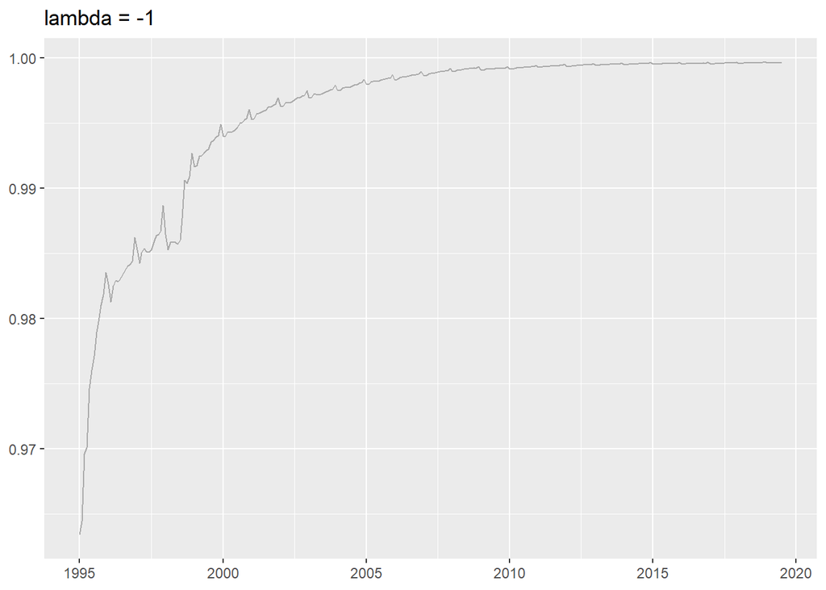

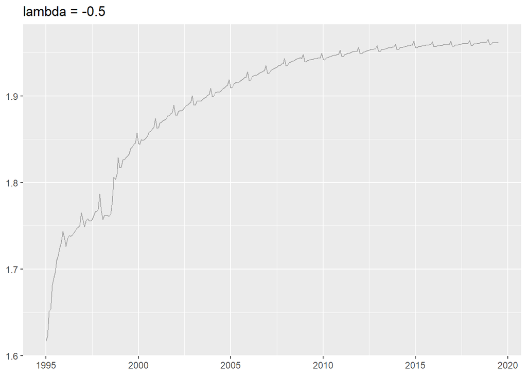

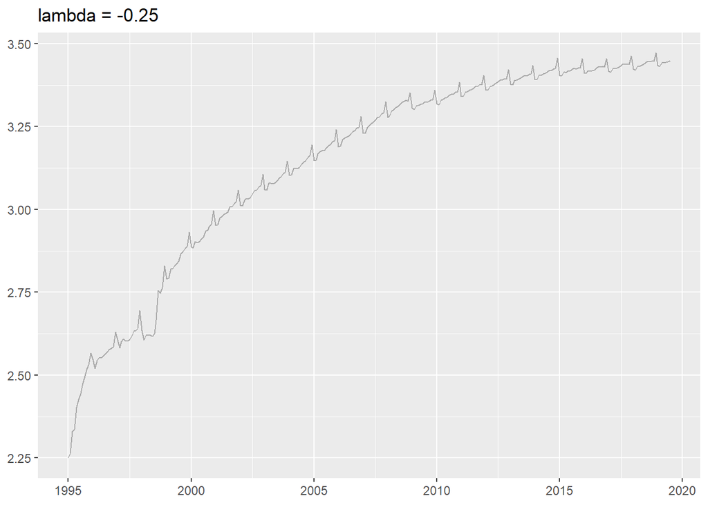

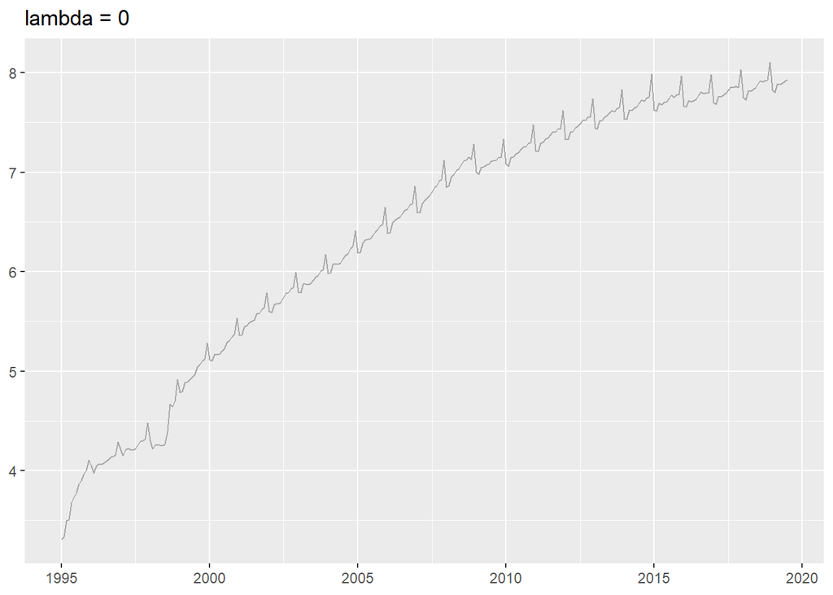

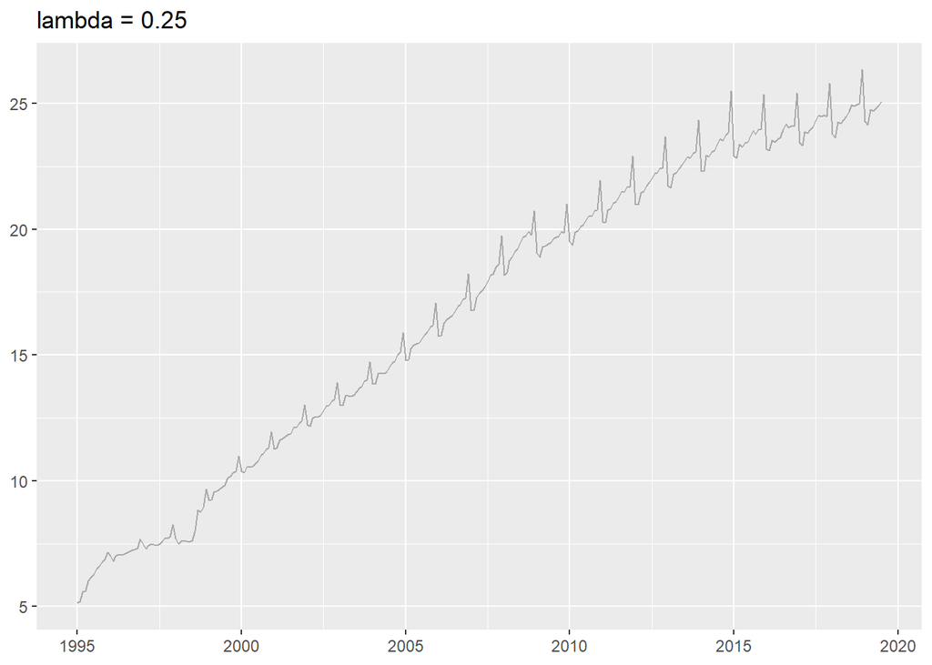

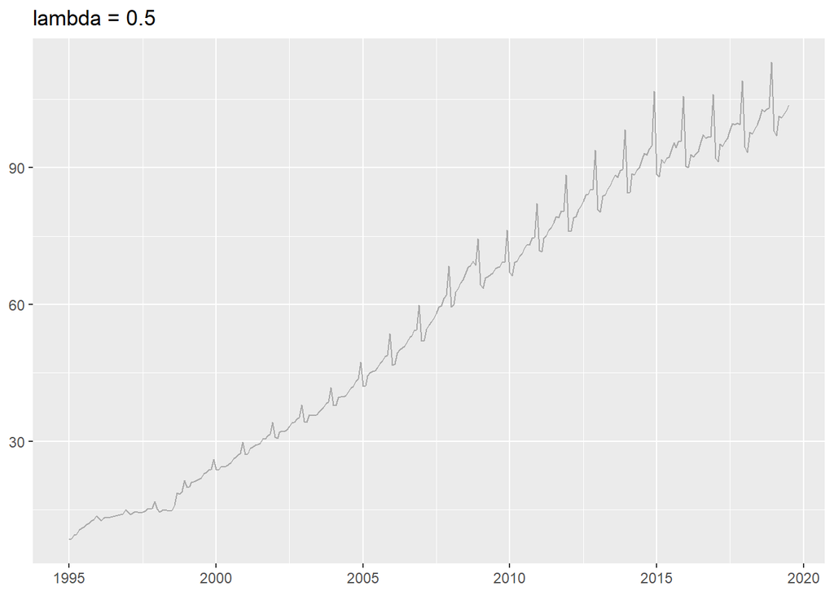

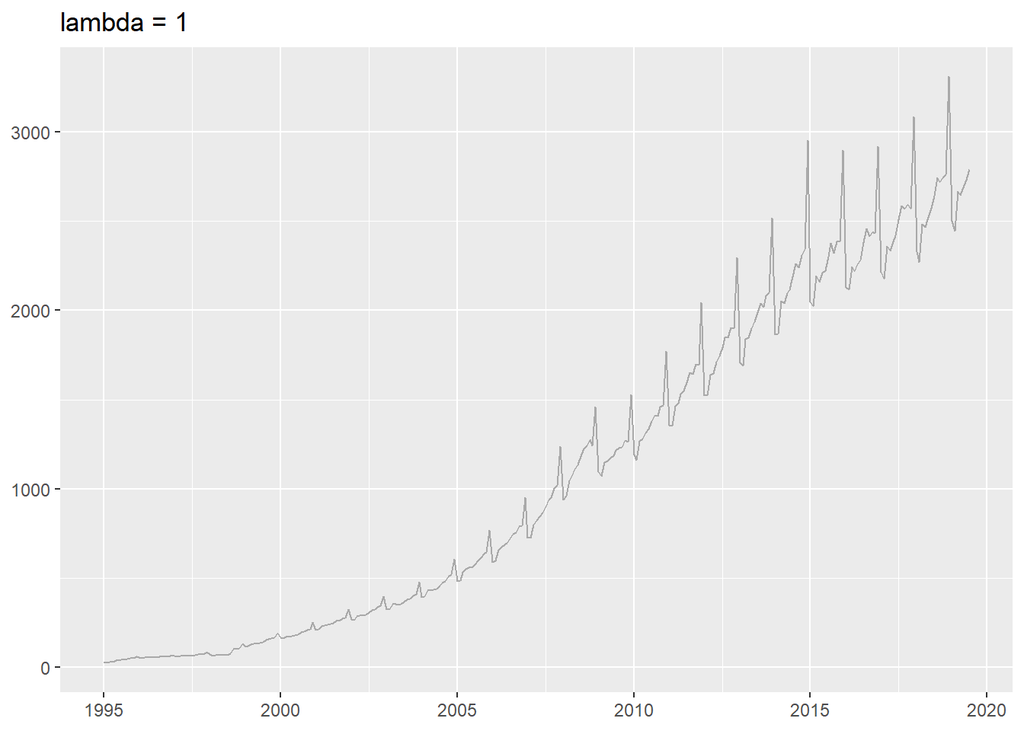

```r
# Параметр преобразования изменяется в цикле
for (lambda in c(-1, -0.5, -0.25, 0, 0.25, 0.5, 1)) {
  p <- autoplot(BoxCox(rtrd, lambda)) +
    labs(title = str_c('lambda = ', lambda),
         x = NULL, y = NULL) +
    geom_line(color = 'darkgray')
  print(p)

}
```

Аналогичный пример, демонстрирующий влияние параметра $\lambda$, можно посмотреть [здесь](http://www.otexts.org/sites/default/files/fpp/images/telec.gif)

Для автоматического подбора $\lambda$, при котором преобразованный ряд наиболее близок к аддитивной сезонной модели, можно использовать функцию `forecast::BoxCox.lambda()`. О применяемых методах подбора параметра $\lambda$ можно прочитать в справке.

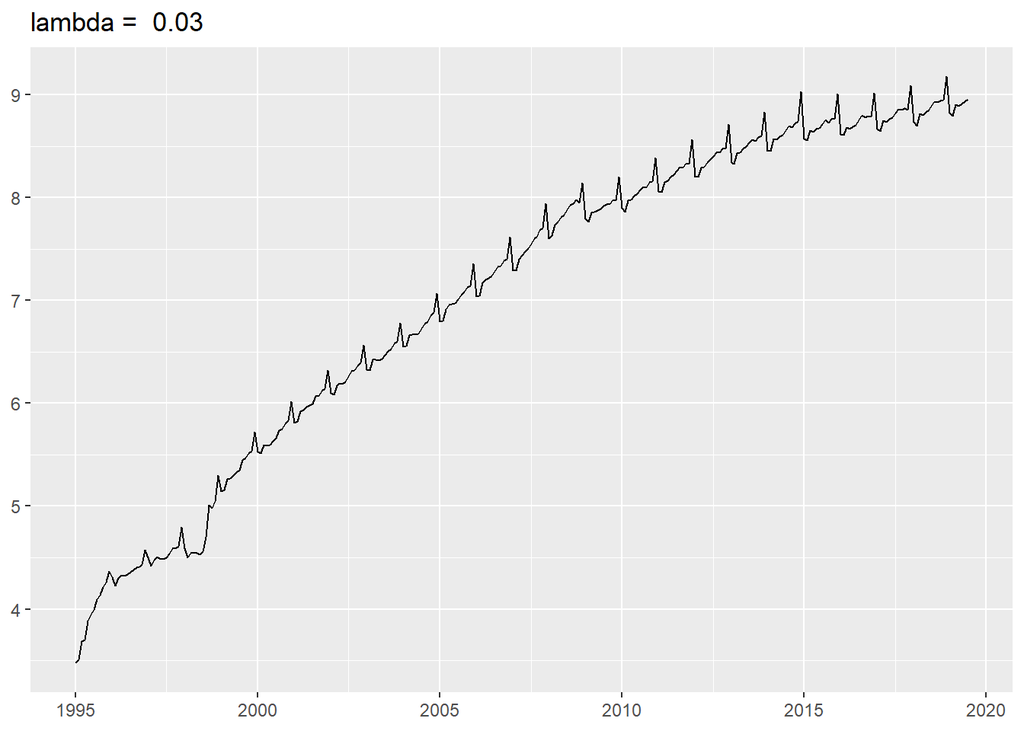

```r
best_lambda <- BoxCox.lambda(rtrd)

autoplot(BoxCox(rtrd, best_lambda)) +
    labs(title = paste('lambda = ', round(best_lambda, 2)),
         x = NULL, y = NULL)
```

Полученное в результате подбора значение параметра можно использовать в качестве ориентира, поскольку дробные значения $\lambda$ затрудняют интерпретацию данных. Например, $\lambda = 0.42$ лучше заменить на $\lambda = 0.5$ (квадратный корень).

В данном случае значение параметра $\lambda$ близко к нулю, следовательно для преобразования лучше всего применять логарифмирование.

Чтобы перейти от преобразованных данных назад к исходным, необходимо применить обратное преобразование (**back-transform**). Математически **обратное преобразование Бокса-Кокса** (**reverse Box-Cox transformation**) задается следующим образом:

$$y_t =
\begin{cases}
\exp(w_t) & \text{при } \lambda = 0 \\
(\lambda w_t + 1) ^ \frac{1}{\lambda} & \text{иначе.}
\end{cases}$$

В R для обратного преобразования Бокса-Кокса используется функция `forecast::InvBoxCox()`.

При использовании преобразований Бокса-Кокса помните о следующих его особенностях:

- При наличии во временном ряде отрицательных или нулевых значений преобразование невозможно. Однако можно прибавить константу ко всем значения ряда, чтобы исключить отрицательные значения.
- Выбирайте легко интерпретируемые значения $\lambda$ (0.37 -> 0.33, или кубический корень).
- Методы прогнозирования слабо чувствительны к изменению параметра $\lambda$
- Часто преобразование не требуется
- Преобразование иногда практически не изменяет точечный прогноз, но сильно влияет на доверительные интервалы для прогноза.